# Analiza danych dotyczących transportu kojewego we Francji

## Autor: Mateusz Śliwka

### Wstęp

Zbiór danych pochodzi z srewisu Kaggle.com (https://www.kaggle.com/gatandubuc/public-transport-traffic-data-in-france). Liczba kolumn: 32 Liczba wierszy: 7806

```python
# użyte bibiloteki

import pandas as pd
import numpy as np
import seaborn as sns
import matplotlib.pyplot as plt
import warnings
warnings.filterwarnings('ignore')
```

```python
data_set = pd.read_csv('Regularities_by_liaisons_Trains_France.csv')
data_set.head()
```

|  | Year | Month | Departure station | Arrival station | Average travel time (min) | Number of expected circulations | Number of cancelled trains | Number of late trains at departure | Average delay of late departing trains (min) | Average delay of all departing trains (min) | ... | Average train delay > 15min | Number of late trains > 30min | Number of late trains > 60min | Period | Delay due to external causes | Delay due to railway infrastructure | Delay due to traffic management | Delay due to rolling stock | Delay due to station management and reuse of material | Delay due to travellers taken into account |
| --- | --- | --- | --- | --- | --- | --- | --- | --- | --- | --- | --- | --- | --- | --- | --- | --- | --- | --- | --- | --- | --- |
| 0 | 2019 | 7.0 | ANGOULEME | PARIS MONTPARNASSE | 131.914980 | 247.0 | 0.0 | 191.0 | 3.576353 | 2.678273 | ... | 32.965873 | 7.0 | 2.0 | 2019-07 | 25.000000 | 15.000000 | 27.500000 | 12.500000 | 2.500000 | 17.500000 |
| 1 | 2019 | 7.0 | PARIS MONTPARNASSE | LA ROCHELLE VILLE | 175.611570 | 242.0 | 0.0 | 178.0 | 9.780805 | 7.033609 | ... | 32.057143 | 14.0 | 2.0 | 2019-07 | 20.000000 | 24.444444 | 26.666667 | 24.444444 | 0.000000 | 4.444444 |
| 2 | 2019 | 7.0 | LE MANS | PARIS MONTPARNASSE | 62.395349 | 435.0 | 5.0 | 391.0 | 3.896974 | 3.529341 | ... | 42.367241 | 13.0 | 4.0 | 2019-07 | 16.176471 | 32.352941 | 26.470588 | 14.705882 | 2.941176 | 7.352941 |
| 3 | 2019 | 7.0 | ST MALO | PARIS MONTPARNASSE | 172.421053 | 114.0 | 0.0 | 101.0 | 1.950990 | 1.685673 | ... | 27.620833 | 2.0 | 0.0 | 2019-07 | 15.384615 | 15.384615 | 23.076923 | 38.461538 | 0.000000 | 7.692308 |
| 4 | 2019 | 7.0 | PARIS MONTPARNASSE | ST PIERRE DES CORPS | 67.310000 | 404.0 | 4.0 | 284.0 | 8.379108 | 5.803125 | ... | 37.658333 | 12.0 | 3.0 | 2019-07 | 18.461538 | 12.307692 | 40.000000 | 16.923077 | 7.692308 | 4.615385 |

5 rows × 32 columns

Do ostatecznej analizy zostały użyte kolumny dotyczą roku oraz miesiąca, w którym wystąpiły opóźnienia oraz liczba opóźnien w podziale na rodzaj przyczyny, która spowodowała opóźnienie.

- 'Delay due to external causes' - opóźnienia z przyczyn zewnętrznych (pogoda, przeszkody, podejrzane pakunki, złośliwe zamiary, ruchy społeczne itp,)
- 'Delay due to railway infrastructure' - spóźnienia z powodu infrastruktury kolejowej (prace konserwacyjne)
- 'Delay due to traffic management'- opóźnienia pociągów spowodowanych zarządzaniem ruchem (ruch na linii kolejowej, interakcje w sieci)
- 'Delay due to rolling stock' - spóźnienia ze względu na tabor kolejowy
- 'Delay due to station management and reuse of material' - opóźnienia pociągów spowodowanych zarządzaniem stacjami i ponownym wykorzystaniem materiałów
- 'Delay due to travellers taken into account' - opóźnienia spowodowane ruchem pasażerskim

```python
df = data_set[['Year', 'Month','Delay due to external causes',
       'Delay due to railway infrastructure',
       'Delay due to traffic management', 'Delay due to rolling stock',
       'Delay due to station management and reuse of material',
       'Delay due to travellers taken into account']].copy()
df.head()
```

|  | Year | Month | Delay due to external causes | Delay due to railway infrastructure | Delay due to traffic management | Delay due to rolling stock | Delay due to station management and reuse of material | Delay due to travellers taken into account |
| --- | --- | --- | --- | --- | --- | --- | --- | --- |
| 0 | 2019 | 7.0 | 25.000000 | 15.000000 | 27.500000 | 12.500000 | 2.500000 | 17.500000 |
| 1 | 2019 | 7.0 | 20.000000 | 24.444444 | 26.666667 | 24.444444 | 0.000000 | 4.444444 |
| 2 | 2019 | 7.0 | 16.176471 | 32.352941 | 26.470588 | 14.705882 | 2.941176 | 7.352941 |
| 3 | 2019 | 7.0 | 15.384615 | 15.384615 | 23.076923 | 38.461538 | 0.000000 | 7.692308 |
| 4 | 2019 | 7.0 | 18.461538 | 12.307692 | 40.000000 | 16.923077 | 7.692308 | 4.615385 |

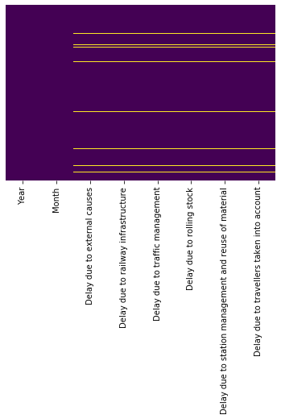

```python
# wizualizacja występowania wartości pustych
sns.heatmap(df.isnull(), yticklabels = False, cbar = False, cmap = 'viridis')
```

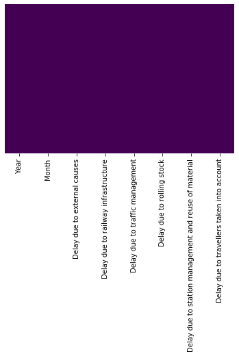

```python
df.dropna(inplace=True)
sns.heatmap(df.isnull(), yticklabels = False, cbar = False, cmap = 'viridis')
```

```python
# Utworzenie kolumny 'Date', zawierającą datę
def month_number_to_text(number):
    if number==1.00:
        return 'January'
    elif number==2.00:
        return 'February'
    elif number==3.00:
        return 'March'
    elif number==4.00:
        return 'April'
    elif number==5.00:
        return 'May'
    elif number==6.00:
        return 'June'
    elif number==7.00:
        return 'July'
    elif number==8.00:
        return 'August'
    elif number==9.00:
        return 'September'
    elif number==10.00:
        return 'October'
    elif number==11.00:
        return 'November'
    elif number==12.00:
        return 'December'
    else:
        return 'Error'


df['Month'] = df.Month.apply(month_number_to_text)
df['Date'] = pd.to_datetime(df['Year'].astype(str) + df['Month'], format='%Y%B')
```

```python
df['Delay due to external causes'] = df['Delay due to external causes'].round(decimals=0)
df['Delay due to railway infrastructure'] = df['Delay due to railway infrastructure'].round(decimals=0)
df['Delay due to traffic management'] = df['Delay due to traffic management'].round(decimals=0)
df['Delay due to rolling stock'] = df['Delay due to rolling stock'].round(decimals=0)
df['Delay due to station management and reuse of material'] = df['Delay due to station management and reuse of material'].round(decimals=0)
df['Delay due to travellers taken into account'] = df['Delay due to travellers taken into account'].round(decimals=0)
```

```python
df.groupby('Year').sum()
```

| Year | Delay due to external causes | Delay due to railway infrastructure | Delay due to traffic management | Delay due to rolling stock | Delay due to station management and reuse of material | Delay due to travellers taken into account |
| --- | --- | --- | --- | --- | --- | --- |
| 2015 | 39211.0 | 33853.0 | 20263.0 | 19328.0 | 10672.0 | 5655.0 |
| 2016 | 38944.0 | 34318.0 | 21407.0 | 17605.0 | 12143.0 | 5266.0 |
| 2017 | 34047.0 | 33104.0 | 27521.0 | 28272.0 | 6913.0 | 4349.0 |
| 2018 | 38330.0 | 34173.0 | 30945.0 | 32276.0 | 8048.0 | 4828.0 |
| 2019 | 37146.0 | 33747.0 | 33804.0 | 27885.0 | 9351.0 | 4779.0 |
| 2020 | 13537.0 | 22956.0 | 10635.0 | 11036.0 | 3930.0 | 2570.0 |

```python
# Zdefiniowanie kolejności występowania miesięcy
months = ["January", "February", "March", "April", "May", "June",
          "July", "August", "September", "October", "November", "December"]
df['Month'] = pd.Categorical(df['Month'], categories=months, ordered=True)
```

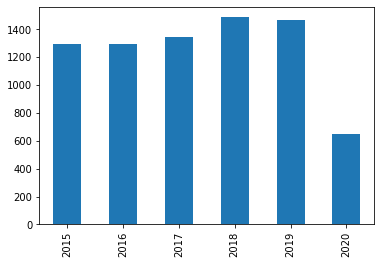

```python
df.Year.value_counts().sort_index().plot.bar()
```

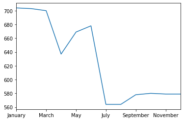

```python
df.Month.value_counts().sort_index().plot()
plt.show()
```

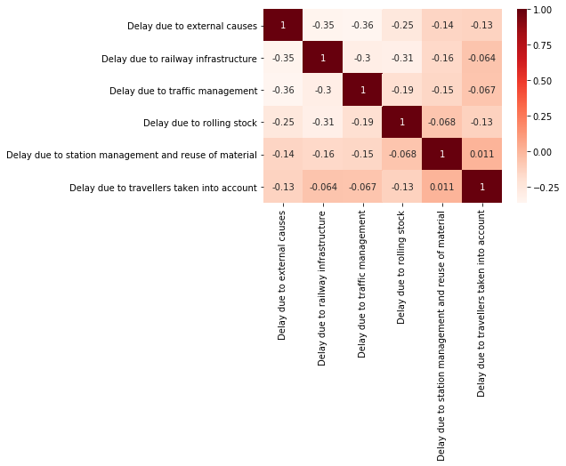

```python
sns.heatmap(df.drop('Year',axis=1).corr(), annot=True, cmap = 'Reds')
plt.show()
```